# Anàlisi dels Ingressos i la Resposta a les Ofertes de màrqueting entre els clients d’iFood al Brasil

Marc Bracons Cucó

5 de junio, 2024

# Introducció

Les dades utilitzades corresponen a iFood, la principal aplicació de lliurament d’aliments al Brasil. L’empresa ven aliments en diverses categories i cerca millorar el rendiment de les activitats de màrqueting. La nova campanya comercial, sisena, té com a objectiu vendre un nou gadget a la base de dades de clients. Es va dur a terme una campanya pilot a la que van participar 2.240 clients. Els clients van ser seleccionats a l’atzar i contactats per telèfon per a l’adquisició del gadget.

El conjunt de dades d’aquesta pràctica es denomina màrqueting.csv. Les variables que conté són:

1. ID: número identificatiu
2. Year_Birth: Any de naixement
3. Education: el nivell educatiu del client (factor amb 5 nivells)
4. Marital_Estatus: l’estat civil del client (factor amb 8 nivells)
5. Income: ingressos anuals del client
6. Kidhome: nombre de nens que habiten amb el client
7. Teenhome: nombre d’adolescents que habiten amb el client
8. Dt_Customer: data d’alta del client en l’empresa
9. Recency: nombre de dies des de l’última compra
10. MntWines: quantitat gastada en vi en els últims 2 anys
11. MntFruits: quantitat gastada en fruita en els últims 2 anys
12. MntMeatProducts: quantitat gastada en carn en els últims 2 anys
13. MntFishProducts: quantitat gastada en peix en els últims 2 anys
14. MntSweetProducts: quantitat gastada en dolços en els últims 2 anys
15. MntGoldProds: quantitat gastada en productes “*gold” en els últims 2 anys
16. NumDealsPurchases: nombre de compres fetes amb descompte
17. NumWebPurchases: nombre de compres fetes a través de la Web
18. NumCatalogPurchases: nombre de compres fetes usant el catàleg
19. NumStorePurchases: nombre de compres fetes directament en botigues
20. NumWebVisitsMonth: nombre de visites a la Web en l’últim mes
21. AcceptedCmp3: 1 si el client accepta l’oferta en la 3r campanya, 0 si no
22. AcceptedCmp4: 1 si el client accepta l’oferta en la 4t campanya, 0 si no
23. AcceptedCmp5: 1 si el client accepta l’oferta en la 5è campanya, 0 si no
24. AcceptedCmp1: 1 si el client accepta l’oferta en la 1r campanya, 0 si no
25. AcceptedCmp2: 1 si el client accepta l’oferta en la 2n campanya, 0 si no
26. Complain: 1 si el client formalitza una queixa en l’últim any
27. Z_CostContact: variable control (s’ha d’excloure de l’anàlisi)
28. Z_Revenue: variable control (s’ha d’excloure de l’anàlisi)
29. Response: 1 si el client accepta l’oferta en l’última campanya, 0 si no

El conjunt de dades original es troba disponible a: https://github.com/nailson/ifood-data-business-analyst- test/blob/master/ifood_df.csv

L’objectiu final és desenvolupar un model que permeti identificar als clients segons les seves característiques. En aquesta activitat s’analitzarà si els ingressos dels clients estan determinats pel nivell educatiu i altres característiques. Per a fer-ho, s’apliquen diferents tipus d’anàlisis, revisant el contrast d’hipòtesis de dues mostres, vist a l’activitat A2, i després realitzant anàlisis més complexes com ANOVA.

# Preprocessament

## Variables Income i Year_Birth

Primer carregarem el fitxer de dades “marketing.csv” i consultarem els tipus de dades de les variables i si és necessari, aplicarem les transformacions apropiades.

```r
data <- read.csv("marketing.csv")
str(data)
```

```
## 'data.frame':    2240 obs. of  29 variables:
##  $ ID                 : int  5524 2174 4141 6182 5324 7446 965 6177 4855 5899 ...
##  $ Year_Birth         : int  1957 1954 1965 1984 1981 1967 1971 1985 1974 1950 ...
##  $ Education          : chr  "Graduation" "Graduation" "Graduation" "Graduation" ...
##  $ Marital_Status     : chr  "Single" "Single" "Together" "Together" ...
##  $ Income             : int  58138 46344 71613 26646 58293 62513 55635 33454 30351 5648 ...
##  $ Kidhome            : int  0 1 0 1 1 0 0 1 1 1 ...
##  $ Teenhome           : int  0 1 0 0 0 1 1 0 0 1 ...
##  $ Dt_Customer        : chr  "2012-09-04" "2014-03-08" "2013-08-21" "2014-02-10" ...
##  $ Recency            : int  58 38 26 26 94 16 34 32 19 68 ...
##  $ MntWines           : int  635 11 426 11 173 520 235 76 14 28 ...
##  $ MntFruits          : int  88 1 49 4 43 42 65 10 0 0 ...
##  $ MntMeatProducts    : int  546 6 127 20 118 98 164 56 24 6 ...
##  $ MntFishProducts    : int  172 2 111 10 46 0 50 3 3 1 ...
##  $ MntSweetProducts   : int  88 1 21 3 27 42 49 1 3 1 ...
##  $ MntGoldProds       : int  88 6 42 5 15 14 27 23 2 13 ...
##  $ NumDealsPurchases  : int  3 2 1 2 5 2 4 2 1 1 ...
##  $ NumWebPurchases    : int  8 1 8 2 5 6 7 4 3 1 ...
##  $ NumCatalogPurchases: int  10 1 2 0 3 4 3 0 0 0 ...
##  $ NumStorePurchases  : int  4 2 10 4 6 10 7 4 2 0 ...
##  $ NumWebVisitsMonth  : int  7 5 4 6 5 6 6 8 9 20 ...
##  $ AcceptedCmp3       : int  0 0 0 0 0 0 0 0 0 1 ...
##  $ AcceptedCmp4       : int  0 0 0 0 0 0 0 0 0 0 ...
##  $ AcceptedCmp5       : int  0 0 0 0 0 0 0 0 0 0 ...
##  $ AcceptedCmp1       : int  0 0 0 0 0 0 0 0 0 0 ...
##  $ AcceptedCmp2       : int  0 0 0 0 0 0 0 0 0 0 ...
##  $ Complain           : int  0 0 0 0 0 0 0 0 0 0 ...
##  $ Z_CostContact      : int  3 3 3 3 3 3 3 3 3 3 ...
##  $ Z_Revenue          : int  11 11 11 11 11 11 11 11 11 11 ...
##  $ Response           : int  1 0 0 0 0 0 0 0 1 0 ...
```

Un cop vistes les dades, podem veure que hi ha algunes transformacions que són necessàries:

- Convertirem les variables categòriques (**Education** i **Marital_Status**) a *factors*.
- Convertirem la variable **Dt_Customer** a un objecte de tipus *Data*.

```r
data$Education <- as.factor(data$Education)
data$Marital_Status <- as.factor(data$Marital_Status)

data$Dt_Customer <- as.Date(data$Dt_Customer, format="%Y-%m-%d")
```

A continuació ens centrarem en les variables **Income** i **Year_Birth**, buscant possibles inconsistències en els seus valors. Per a fer-ho, primer de tot hem mirat que l’última actualització de les dades en el repositori av ser el 19/02/2020, així que dates posteriors a aquest dia no tenen sentit.

Assumirem: * No hi pot haver valors de **Income** negatius. * Cap client pot tindre més de 100 anys ni menys de 18.

Abans però, visualitzarem les variables per a tindre informació visual.

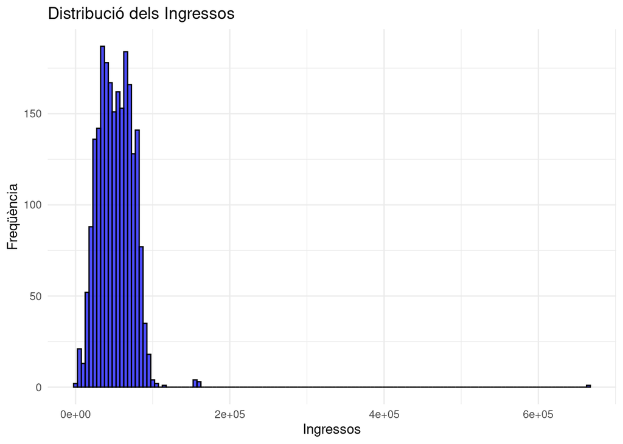

```r
library(ggplot2)

ggplot(data, aes(x = Income)) +
  geom_histogram(binwidth = 5000, fill = "blue", color = "black", alpha = 0.7) +
  labs(title = "Distribució dels Ingressos", x = "Ingressos", y = "Freqüència") +
  theme_minimal()
```

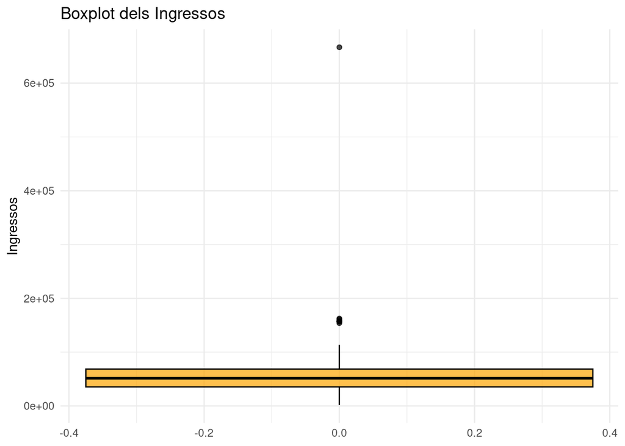

```r
ggplot(data, aes(y = Income)) +
  geom_boxplot(fill = "orange", color = "black", alpha = 0.7) +
  labs(title = "Boxplot dels Ingressos", y = "Ingressos") +
  theme_minimal()
```

```r
summary(data$Year_Birth)
```

```
##    Min. 1st Qu.  Median    Mean 3rd Qu.    Max.
##    1893    1959    1970    1969    1977    1996
```

```r
summary(data$Income)
```

```
##    Min. 1st Qu.  Median    Mean 3rd Qu.    Max.    NA's
##    1730   35303   51382   52247   68522  666666      24
```

A les gràfiques podem veure clarament com hi ha valors atípics a la variable **Income**. Per eliminar-los el que farem és establir una cota superior raonable, de valor 200000. Els valors per sobre de la cota, seran substituïts per **NA**. Aplicarem també els filtres discutits anteriorment.

```r
library(dplyr)
library(lubridate)
current_year <- 2020
data <- data %>%
  mutate(Year_Birth = ifelse(Year_Birth < 1900 | Year_Birth > (current_year - 18), NA, Year_Birth))

age_limit <- 100
data <- data %>%
  mutate(Year_Birth = ifelse((current_year - Year_Birth) > age_limit, NA, Year_Birth))

income_upper_limit <- 200000
data <- data %>% mutate(Income = ifelse(Income < 0 | Income > income_upper_limit, NA, Income))

summary(data$Year_Birth)
```

```
##    Min. 1st Qu.  Median    Mean 3rd Qu.    Max.    NA's
##    1940    1959    1970    1969    1977    1996       3
```

```r
summary(data$Income)
```

```
##    Min. 1st Qu.  Median    Mean 3rd Qu.    Max.    NA's
##    1730   35284   51373   51970   68487  162397      25
```

## Valors absents

Ara farem tractament per a valors absents. Adoptarem la següent estratègia:

- El tractament de la variable Income en cas de valors perduts, aplicarem imputació per veïns més pròxims, utilitzant la distància de Gower, considerant en el còmput dels veïns més pròxims les variables numèriques que representen la despesa en els diferents productes (variables de la 10 a la 15).
- En cas de valors perduts de la variable Year_Birth, aplicarem imputació considerant el valor mitjà de la variable Year_Birth entre les persones enquestades en estat civil “Vidu/a”
- Eliminarem les observacions amb valors absents per a la resta de variables del conjunt de dades.
- Revisarem en quantes observacions hem trobat valors absents

La funció **kNN* de la llibreria** VIM* fa servir la distància de Gower per defecte quan es treballa amb variables numèrqiues i categòriques, tal i com és el nostre cas.

```r
library(VIM)
library(tidyr)

missing_values_summary <- colSums(is.na(data))
print(missing_values_summary)
```

```
##                  ID          Year_Birth           Education      Marital_Status
##                   0                   3                   0                   0
##              Income             Kidhome            Teenhome         Dt_Customer
##                  25                   0                   0                   0
##             Recency            MntWines           MntFruits     MntMeatProducts
##                   0                   0                   0                   0
##     MntFishProducts    MntSweetProducts        MntGoldProds   NumDealsPurchases
##                   0                   0                   0                   0
##     NumWebPurchases NumCatalogPurchases   NumStorePurchases   NumWebVisitsMonth
##                   0                   0                   0                   0
##        AcceptedCmp3        AcceptedCmp4        AcceptedCmp5        AcceptedCmp1
##                   0                   0                   0                   0
##        AcceptedCmp2            Complain       Z_CostContact           Z_Revenue
##                   0                   0                   0                   0
##            Response
##                   0
```

```r
data <- kNN(data, variable = "Income", dist_var = c("MntWines", "MntFruits", "MntMeatProducts", "MntFishProducts", "MntSweetProducts", "MntGoldProds"), k = 5)

data <- subset(data, select = -Income_imp)

mean_year_birth_widow <- mean(data$Year_Birth[data$Marital_Status == "Widow"], na.rm = TRUE)
data <- data %>%
  mutate(Year_Birth = ifelse(is.na(Year_Birth) & Marital_Status == "Widow", mean_year_birth_widow, Year_Birth))

final_na_count <- sum(is.na(data))
cat("Nombre final de valors NA després de la imputació:", final_na_count, "\n")
```

```
## Nombre final de valors NA després de la imputació: 3
```

```r
markclean <- data %>% drop_na()

final_na_count <- sum(is.na(markclean))
cat("Nombre final de valors NA després de la neteja:", final_na_count, "\n")
```

```
## Nombre final de valors NA després de la neteja: 0
```

La imputació amb kNN és un mètode efectiu per estimar valors faltants, tot i això, fer una imputació precisa requereix un alt cost computacional i, la qualitat d’aquesta depèn del nombre de veïns usats. També hem usat la mitjana, un mètode més simple però efectiu quan es treballa amb pocs valors faltants.

Finalment, s’han eliminat 3 registres. Això no és preocupant ja que el joc de dades original consta de 2240 observacions, fent que aquesta eliminació no tingui un impacte significatiu en les dades.

# Estadística descriptiva

## Income

El coeficient de variació (*Desviació estàndar/valor absolut de la mitjana*) es fa servir per analitzar si la mitjana és representativa. Un coeficient de variació més petit a 1 es considera que la mitjana és un valor representatiu del conjunt de les dades. Calcularem el coeficient de variació de la variable $Income$.

```r
mean_income <- mean(markclean$Income, na.rm = TRUE)
sd_income <- sd(markclean$Income, na.rm = TRUE)

cv_income <- sd_income / abs(mean_income)
cat("Coeficient de variació de la variable Income:", cv_income, "\n")
```

```
## Coeficient de variació de la variable Income: 0.4160962
```

El coeficient de variació és 0.416, cosa que ens indica que la mitjana és un valor representatiu de la distribució dels ingressos.

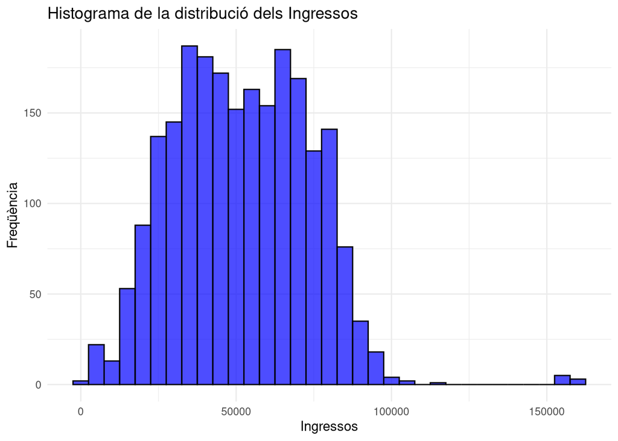

```r
library(ggplot2)

# Histograma
ggplot(markclean, aes(x = Income)) +
  geom_histogram(binwidth = 5000, fill = "blue", color = "black", alpha = 0.7) +
  labs(title = "Histograma de la distribució dels Ingressos", x = "Ingressos", y = "Freqüència") +
  theme_minimal()
```

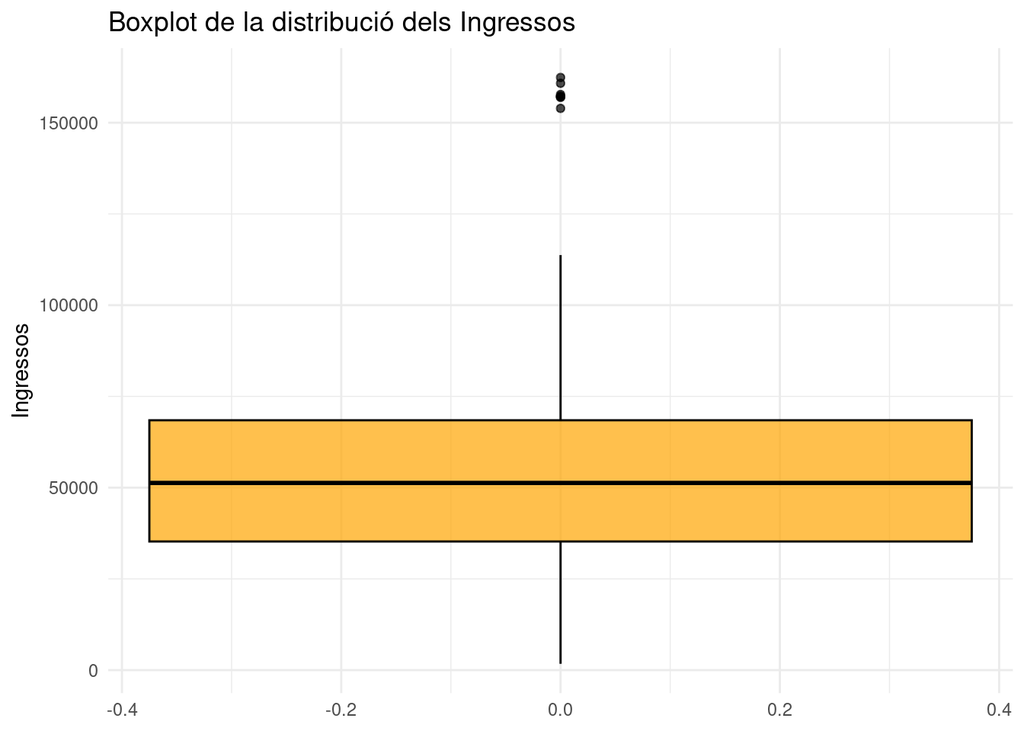

```r
# Boxplot
ggplot(markclean, aes(y = Income)) +
  geom_boxplot(fill = "orange", color = "black", alpha = 0.7) +
  labs(title = "Boxplot de la distribució dels Ingressos", y = "Ingressos") +
  theme_minimal()
```

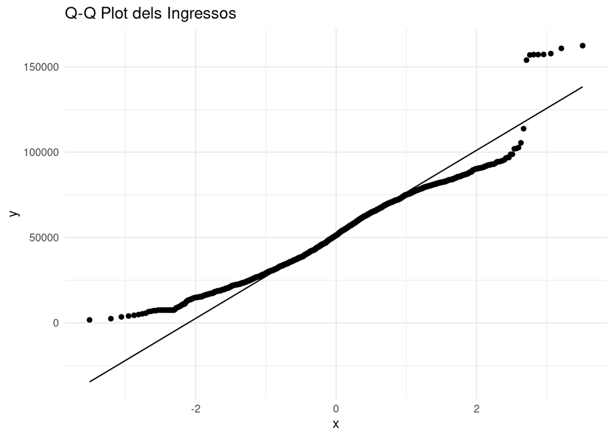

```r
# QQ plot
ggplot(markclean, aes(sample = Income)) +
  stat_qq() +
  stat_qq_line() +
  labs(title = "Q-Q Plot dels Ingressos") +
  theme_minimal()
```

- L’histograma ens mostra una distribució molt simètrica amb una lleugera desviació a la dreta. La majoria dels ingressos estan concentrats entre els 20000 i els 80000 amb alguns valors més elevats a la cua de la dreta.
- El boxplot ens mostra una distribució simètrica amb alguns valors atípics per sobre dels 100000, però la majoria de les dades es troben dins del rang interquartil.
- El QQ plot ens mostra que els ingressos no segueixen estrictament una distribució normal. La desviació dels punts de la línia diagonal ens indica que la distribució té una cua llarga a la dreta (cosa que és consistent amb l’histograma). Els punts que es desvien significativament de la línia diagonal, sobretot als extrems, ens indiquen que la distribució no és perfectament normal.

Així doncs, tot i que la mitjana pot ser un valor útil per resumir els ingressos, cal tenir en compte la desviació de la normalitat durant l’anàlisi.

## Education

Mostrem en una taula els estadístics descriptius (mitjana, nombre d’observacions i desviació típica) dels ingressos segons el nivell educatiu.

```r
markclean$Education <- factor(markclean$Education, levels = c("PhD", "Master", "Graduation", "2n Cycle", "Basic"))

descriptive_stats <- markclean %>%
  group_by(Education) %>%
  summarize(
    Mean_Income = mean(Income, na.rm = TRUE),
    Count = n(),
    SD_Income = sd(Income, na.rm = TRUE)
  )

print(descriptive_stats)
```

```
## # A tibble: 5 × 4
##   Education  Mean_Income Count SD_Income
##   <fct>            <dbl> <int>     <dbl>
## 1 PhD             56005.   485    20527.
## 2 Master          53014.   370    20082.
## 3 Graduation      52040.  1127    21376.
## 4 2n Cycle        48047.   201    23385.
## 5 Basic           20306.    54     6235.
```

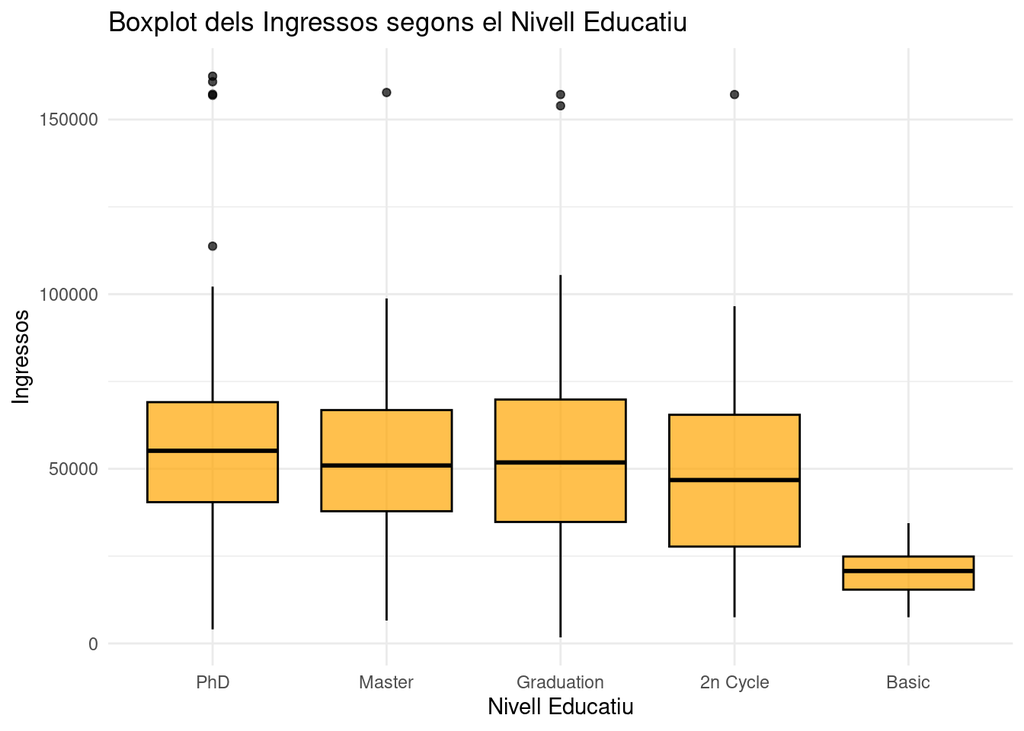

```r
ggplot(markclean, aes(x = Education, y = Income)) +
  geom_boxplot(fill = "orange", color = "black", alpha = 0.7) +
  labs(title = "Boxplot dels Ingressos segons el Nivell Educatiu", x = "Nivell Educatiu", y = "Ingressos") +
  theme_minimal()
```

En quant al boxplot, observem que no hi ha valors atípics en el nivell educatiu b`aàsic, en la resta sí. Això pot ser degut a algunes persones amb ingressos significativament més alts que la resta, possiblement per posicions laborals molt ben pagades o altres fonts d’ingressos.

# Estadística inferencial

## Contrast d’hipòtesi per a la diferència de mitjanes

A continuació voldem saber si podem acceptar que els **ingressos mitjans de les persones sense estudis universitaris són inferiors als de les persones amb estudis universitaris**

### Escriviu la hipòtesi nul·la i l’alternativa

Primer formularem les hipòtesis nul·la i alternativa,

- **Hipòtesi nul·la (H0):** Els ingressos mitjans de les persones sense estudis universitaris són iguals o superiors als de les persones amb estudis universitaris.

$H0: \mu_{no\_universitaris}\geq\mu_{universitaris}$

- **Hipòtesi alternativa (H1):** Els ingressos mitjans de les persones sense estudis universitaris són inferiors als de les persones amb estudis universitaris.

$H1: \mu_{no\_universitaris}<\mu_{universitaris}$

### Justificació del test a aplicar

Utilitzarem un test de diferència de mitjanes per a mostres independents (test t de Welch) per comparar els ingressos mitjans de les persones amb i sense estudis universitaris. Farem servir aquest test per les següents raons:

- Mostres independents: Les dades obtingudes de les persones amb i sense estudis universitaris són independents ja que els individus d’un grup no influeixen en els individus de l’altre grup.
- Comparació de mitjanes: Volem comparar les mitjanes dels dos grups per veure si hi ha una diferència significativa entre els ingressos.
- Variàncies diferents: Suposem que les variàncies dels ingressos en els dos grups poden ser diferents, ja que hem vist diferències en la dispersió dels ingressos quan hem fet l’estudi previ amb els diagrames de caixa.
- Assumirem Normalitat: Encara que hem vist que els ingressos no segueixen una distribució normal perfecta, al tindre una mostra prou gran podem fer servir aquest test, que té una desviació moderada respecte a una distribució normal.

### Càlculs

Realitzarem els càlculs de l’estadístic de contrast, valor crític i p valor a un nivell de confiança del 99%

```r
library(dplyr)

no_universitaris <- markclean %>% filter(Education %in% c("Basic", "2n Cycle"))
universitaris <- markclean %>% filter(Education %in% c("Graduation", "Master", "PhD"))

mean_no_universitaris <- mean(no_universitaris$Income, na.rm = TRUE)
sd_no_universitaris <- sd(no_universitaris$Income, na.rm = TRUE)
n_no_universitaris <- nrow(no_universitaris)

mean_universitaris <- mean(universitaris$Income, na.rm = TRUE)
sd_universitaris <- sd(universitaris$Income, na.rm = TRUE)
n_universitaris <- nrow(universitaris)

t_stat <- (mean_no_universitaris - mean_universitaris) / sqrt((sd_no_universitaris^2 / n_no_universitaris) + (sd_universitaris^2 / n_universitaris))

df <- ((sd_no_universitaris^2 / n_no_universitaris) + (sd_universitaris^2 / n_universitaris))^2 /
  ((sd_no_universitaris^2 / n_no_universitaris)^2 / (n_no_universitaris - 1) + (sd_universitaris^2 / n_universitaris)^2 / (n_universitaris - 1))

t_crit <- qt(0.01, df, lower.tail = TRUE)
p_valor <- pt(t_stat, df)

cat("Mitjana Ingressos (No Universitaris):", mean_no_universitaris, "\n")
```

```
## Mitjana Ingressos (No Universitaris): 42172.78
```

```r
cat("Desviació Estàndard (No Universitaris):", sd_no_universitaris, "\n")
```

```
## Desviació Estàndard (No Universitaris): 23825.73
```

```r
cat("Nombre d'Observacions (No Universitaris):", n_no_universitaris, "\n")
```

```
## Nombre d'Observacions (No Universitaris): 255
```

```r
cat("Mitjana Ingressos (Universitaris):", mean_universitaris, "\n")
```

```
## Mitjana Ingressos (Universitaris): 53192.06
```

```r
cat("Desviació Estàndard (Universitaris):", sd_universitaris, "\n")
```

```
## Desviació Estàndard (Universitaris): 20987.82
```

```r
cat("Nombre d'Observacions (Universitaris):", n_universitaris, "\n")
```

```
## Nombre d'Observacions (Universitaris): 1982
```

```r
cat("Estadístic del Test (t):", t_stat, "\n")
```

```
## Estadístic del Test (t): -7.042279
```

```r
cat("Graus de Llibertat (df):", df, "\n")
```

```
## Graus de Llibertat (df): 306.8551
```

```r
cat("Valor Crític (t_crit):", t_crit, "\n")
```

```
## Valor Crític (t_crit): -2.338561
```

```r
cat("p-valor:", p_valor, "\n")
```

```
## p-valor: 6.230018e-12
```

### Interpretació del test

Podem veure que les persones amb estudis universitaris tenen una mitjana d’ingressos superior a les persones sense estudis universitaris. També la variabilitat dels ingressos és lleugerament superior per a les persones sense estudis universitaris.

Crida l’atenció que en aquest joc de dades el nombre d’individus amb estudis universitaris és considerablement més gran que el nombre d’individus sense estudis universitaris. En un futur anàlisi es podria mirar si això s’ajusta a la població real o es tracta d’un joc de dades desbalancejat.

Pel que fa a l’estadístic, el seu valor és $t=-7.042279$, un valor negatiu que ens indica que la mitjana dels ingressos dels no universitaris és inferior a la dels universitaris. També hem obtingut que el valor per rebutjar la hipòtesis nul·la ha de ser menor al valor crític $t_{crit}=-2.3386$. El $p_{valor}=6.23e-12$ és significativament menor que el nivell de confiança del 0.01.

Amb tot això podem rebutjar la hipòtesi nul·la, cosa que significa que hi ha prou evidència com per dir que **els ingressos mitjans de les persones sense estudis universitaris són inferiors als de les persones amb estudis universitaris**.

# Model de regressió

## Regressió lineal múltiple

Per investigar quines variables expliquen els ingressos dels individus, estimarem un model de regressió lineal múltiple amb les variables Year_Birth, Kidhome, Teenhome, Education, MntWines, MntFruits, MntMeatProducts, MntFishProducts, MntSweetProducts, MntGoldProds, NumDealsPurchases, NumCatalogPurchases, NumStorePurchases i NumWebVisitsMonth. La categoria de referència per a la variable **Education** serà **Basic**.

```r
markclean$Education <- relevel(markclean$Education, ref = "Basic")

model <- lm(Income ~ Year_Birth + Kidhome + Teenhome + Education + MntWines + MntFruits + MntMeatProducts +
            MntFishProducts + MntSweetProducts + MntGoldProds + NumDealsPurchases + NumCatalogPurchases +
            NumStorePurchases + NumWebVisitsMonth, data = markclean)

summary(model)
```

```
##
## Call:
## lm(formula = Income ~ Year_Birth + Kidhome + Teenhome + Education +
##     MntWines + MntFruits + MntMeatProducts + MntFishProducts +
##     MntSweetProducts + MntGoldProds + NumDealsPurchases + NumCatalogPurchases +
##     NumStorePurchases + NumWebVisitsMonth, data = markclean)
##
## Residuals:
##    Min     1Q Median     3Q    Max
## -95041  -5901     97   5730 110551
##
## Coefficients:
##                       Estimate Std. Error t value Pr(>|t|)
## (Intercept)          1.044e+05  4.292e+04   2.433  0.01505 *
## Year_Birth          -3.528e+01  2.174e+01  -1.623  0.10472
## Kidhome              1.118e+03  5.683e+02   1.968  0.04923 *
## Teenhome             6.269e+03  5.207e+02  12.038  < 2e-16 ***
## EducationPhD         1.344e+04  1.592e+03   8.440  < 2e-16 ***
## EducationMaster      1.223e+04  1.603e+03   7.631 3.44e-14 ***
## EducationGraduation  1.170e+04  1.525e+03   7.667 2.61e-14 ***
## Education2n Cycle    1.146e+04  1.660e+03   6.904 6.56e-12 ***
## MntWines             1.802e+01  1.060e+00  17.003  < 2e-16 ***
## MntFruits            1.917e+01  7.919e+00   2.421  0.01556 *
## MntMeatProducts      2.318e+01  1.680e+00  13.802  < 2e-16 ***
## MntFishProducts      9.591e+00  5.993e+00   1.600  0.10964
## MntSweetProducts     3.062e+01  7.467e+00   4.101 4.26e-05 ***
## MntGoldProds         5.896e-01  5.232e+00   0.113  0.91028
## NumDealsPurchases   -4.459e+02  1.481e+02  -3.011  0.00263 **
## NumCatalogPurchases  6.897e+02  1.329e+02   5.192 2.28e-07 ***
## NumStorePurchases    6.181e+02  1.046e+02   5.911 3.92e-09 ***
## NumWebVisitsMonth   -2.634e+03  1.314e+02 -20.042  < 2e-16 ***
## ---
## Signif. codes:  0 '***' 0.001 '**' 0.01 '*' 0.05 '.' 0.1 ' ' 1
##
## Residual standard error: 10690 on 2219 degrees of freedom
## Multiple R-squared:  0.7573, Adjusted R-squared:  0.7555
## F-statistic: 407.4 on 17 and 2219 DF,  p-value: < 2.2e-16
```

El valor **Multiple R-squared** ens indica que el 75.73% de la variabilitat en els ingressos es pot explicar amb les variables incloses en el model. L’alt valor de **F-statistic** i el baix valor de **p-value** ens indiquen que el model en conjunt és significativamnet millor que un model sense variables explicatives.

Pel que fa a les variables, la columna **Estimate** ens indica l’efecte de cada variable explicativa sobre **Income**; els valors **p** associats n’indiquen la significança estadística.

Amb tot això, podem treure les següents conclusions:

- Educació: Els nivells educatius més alts tenen una associació positiva significativa amb ingressos més alts en comparació amb el nivell educatiu **Basic**
- Despeses en Productes: Despeses més altes en vins, carns, fruites i productes dolços estan associades amb ingressos més alts.
- Nombre de Compres i Visites: Més compres a la botiga i per catàleg estan associades amb ingressos més alts, mentre que més compres amb descomptes i visites a la web estan associades amb ingressos més baixos.
- Altres Factors: Tenir més nens i adolescents a casa també sembla estar associat amb ingressos més alts.

### Multicolinealitat

Per analitzar possibles problemes de multicolinealitat utilitzarem el factor d’inflació de la variància (vif). Valors de VIF més grans que 10 solen indicar problemes de multicolinealitat.

```r
library(car)
vif_values <- vif(model)
print(vif_values)
```

```
##                         GVIF Df GVIF^(1/(2*Df))
## Year_Birth          1.267188  1        1.125694
## Kidhome             1.833476  1        1.354059
## Teenhome            1.574682  1        1.254863
## Education           1.240889  4        1.027346
## MntWines            2.491700  1        1.578512
## MntFruits           1.936948  1        1.391743
## MntMeatProducts     2.813602  1        1.677380
## MntFishProducts     2.099523  1        1.448973
## MntSweetProducts    1.861764  1        1.364465
## MntGoldProds        1.452477  1        1.205188
## NumDealsPurchases   1.604239  1        1.266586
## NumCatalogPurchases 2.953648  1        1.718618
## NumStorePurchases   2.262985  1        1.504322
## NumWebVisitsMonth   1.991321  1        1.411142
```

Tots els valors estan per sota de 10, indicant que no hi ha problemes de multicolinealitat entre les variables explicatives del model.

## Regressió logística

### Model predictiu

Ajustarem un model predictiu basat en la regressió logística per a predir la probabilitat d’acceptar l’oferta en la sisena campanya en funció del nombre de compres amb descompte, el nombre de visites de l’últim mes a la web i si ha acceptat alguna oferta en campanyes prèvies. Mostreu el resultat del model i interpreteu el model en termes de: quines són les variables significatives i com és la qualitat del model.

```r
library(caret)
library(pROC)
model_logistic <- glm(Response ~ NumDealsPurchases + NumWebVisitsMonth + AcceptedCmp1 + AcceptedCmp2 + AcceptedCmp3 + AcceptedCmp4 + AcceptedCmp5,
                      data = markclean, family = binomial)

summary(model_logistic)
```

```
##
## Call:
## glm(formula = Response ~ NumDealsPurchases + NumWebVisitsMonth +
##     AcceptedCmp1 + AcceptedCmp2 + AcceptedCmp3 + AcceptedCmp4 +
##     AcceptedCmp5, family = binomial, data = markclean)
##
## Coefficients:
##                   Estimate Std. Error z value Pr(>|z|)
## (Intercept)       -3.13449    0.19607 -15.986  < 2e-16 ***
## NumDealsPurchases  0.08110    0.03356   2.417  0.01565 *
## NumWebVisitsMonth  0.09520    0.03113   3.058  0.00223 **
## AcceptedCmp1       1.49145    0.22696   6.571 4.99e-11 ***
## AcceptedCmp2       0.91622    0.49680   1.844  0.06515 .
## AcceptedCmp3       1.83307    0.18908   9.695  < 2e-16 ***
## AcceptedCmp4       0.56563    0.22964   2.463  0.01377 *
## AcceptedCmp5       1.99074    0.22866   8.706  < 2e-16 ***
## ---
## Signif. codes:  0 '***' 0.001 '**' 0.01 '*' 0.05 '.' 0.1 ' ' 1
##
## (Dispersion parameter for binomial family taken to be 1)
##
##     Null deviance: 1885.8  on 2236  degrees of freedom
## Residual deviance: 1538.6  on 2229  degrees of freedom
## AIC: 1554.6
##
## Number of Fisher Scoring iterations: 5
```

Variables significatives:

- Les variables NumDealsPurchases, NumWebVisitsMonth, AcceptedCmp1, AcceptedCmp3, AcceptedCmp4, AcceptedCmp5 són significatives, és a dir, tenen un efecte estadísticament significatiu en la probabilitat d’acceptar l’oferta en la sisena campanya.
- AcceptedCmp2 és marginalment significativa amb un p-valor de 0.06515.

Coeficients positius:

- Els coeficients positius per NumDealsPurchases i NumWebVisitsMonth indiquen que un augment en el nombre de compres amb descompte i visites a la web incrementa la probabilitat d’acceptar l’oferta.
- Els coeficients positius per AcceptedCmp1, AcceptedCmp3, AcceptedCmp4, AcceptedCmp5 indiquen que els clients que han acceptat ofertes en campanyes anteriors tenen una major probabilitat d’acceptar l’oferta en la sisena campanya.

### Matriu de confusió

A continuació analitzarem la precisió del model, comparant la predicció del model sobre les mateixes dades del conjunt de dades. Assumirem que la predicció del model és 1 (Response) si la probabilitat del model de regressió logística és superior o igual a 0.5 i 0 en cas contrari.

```r
pred_prob <- predict(model_logistic, type = "response")

pred_class <- ifelse(pred_prob > 0.5, 1, 0)

conf_matrix <- confusionMatrix(as.factor(pred_class), as.factor(markclean$Response))

cat("Matriu de Confusió:\n")
```

```
## Matriu de Confusió:
```

```r
print(conf_matrix)
```

```
## Confusion Matrix and Statistics
##
##           Reference
## Prediction    0    1
##          0 1869  263
##          1   34   71
##
##                Accuracy : 0.8672
##                  95% CI : (0.8525, 0.881)
##     No Information Rate : 0.8507
##     P-Value [Acc > NIR] : 0.01417
##
##                   Kappa : 0.2714
##
##  Mcnemar's Test P-Value : < 2e-16
##
##             Sensitivity : 0.9821
##             Specificity : 0.2126
##          Pos Pred Value : 0.8766
##          Neg Pred Value : 0.6762
##              Prevalence : 0.8507
##          Detection Rate : 0.8355
##    Detection Prevalence : 0.9531
##       Balanced Accuracy : 0.5974
##
##        'Positive' Class : 0
##
```

Podem veure que el model fa prediccions correctes el 86.72% de les vegades. A més, la sensibilitat és molt alta (98.21%), això vol dir que el model detecta correctament els casos en què l’oferta no és acceptada. Per altra banda, l’especificitat és baixa (21.26%), cosa que significa que el model detecta correctament només el 21.26% dels casos en què l’oferta és acceptada.

Així doncs, observem un desequilibri en les classes que pot ser un problema, ja que la major part dels clients no accepten l’oferta, cosa que pot influir en la precisió de la predicció del model. Per tant, aquest model no és prou bo, ja que té un elevat nombre de falsos negatius.

### Predicció

Per a fer una predicció de la probabilitat que un client accepti l’última oferta tenint en compte que ha comprat 5 vegades amb descompte, que ha visitat 10 vegades la web i ha acceptat totes les ofertes de campanyes prèvies, farem servir la següent fórmula de regressió logística:

$log(\frac{p}{1-p})=\beta_0+\beta_1 X_1 +\beta2X_2+...+\beta_nX_n$

On $p$ és la probabilitat d’acceptar l’oferta i $\beta_i$ són els coeficients. Després transformarem el logit obtingut a probabilitat.

```r
intercept <- -3.13449
coef_NumDealsPurchases <- 0.08110
coef_NumWebVisitsMonth <- 0.09520
coef_AcceptedCmp1 <- 1.49145
coef_AcceptedCmp2 <- 0.91622
coef_AcceptedCmp3 <- 1.83307
coef_AcceptedCmp4 <- 0.56563
coef_AcceptedCmp5 <- 1.99074

NumDealsPurchases <- 5
NumWebVisitsMonth <- 10
AcceptedCmp1 <- 1
AcceptedCmp2 <- 1
AcceptedCmp3 <- 1
AcceptedCmp4 <- 1
AcceptedCmp5 <- 1

logit_p <- intercept +
           coef_NumDealsPurchases * NumDealsPurchases +
           coef_NumWebVisitsMonth * NumWebVisitsMonth +
           coef_AcceptedCmp1 * AcceptedCmp1 +
           coef_AcceptedCmp2 * AcceptedCmp2 +
           coef_AcceptedCmp3 * AcceptedCmp3 +
           coef_AcceptedCmp4 * AcceptedCmp4 +
           coef_AcceptedCmp5 * AcceptedCmp5

prob_manual <- exp(logit_p) / (1 + exp(logit_p))
cat("Probabilitat calculada manualment:", prob_manual, "\n")
```

```
## Probabilitat calculada manualment: 0.9934396
```

Per una altre banda repetirem el càlcul però fent servir la funció **predict** de R.

```r
new_data <- data.frame(
  NumDealsPurchases = 5,
  NumWebVisitsMonth = 10,
  AcceptedCmp1 = 1,
  AcceptedCmp2 = 1,
  AcceptedCmp3 = 1,
  AcceptedCmp4 = 1,
  AcceptedCmp5 = 1
)

prob_predict <- predict(model_logistic, newdata = new_data, type = "response")
cat("Probabilitat calculada amb predict:", prob_predict, "\n")
```

```
## Probabilitat calculada amb predict: 0.9934397
```

Les probabilitats calculades manualment i amb la funció **predict** són pràcticament idèntiques amb un valor de 0.9934. A més, el seu alt valor ens indica que la probabilitat que el client accepti l’oferta de la sisena campanya és molt alta.

# ANOVA unifactorial

A continuació es realitzarà una anàlisi de variància, on es desitja comparar els ingressos per als diferents nivells educatius. L’anàlisi de variància consisteix a avaluar si la variabilitat d’una variable dependent pot explicar-se a partir d’una o diverses variables independents, denominades factors. En el supòsit que ens ocupa, ens interessa avaluar si la variabilitat de la variable Income pot explicar-se pel nivell educatiu.

Hi ha dues preguntes bàsiques a respondre:

- Existeixen diferències en els ingressos (Income) entre els diferents nivells educatius?
- Si existeixen diferències, entre quins nivells educatius es donen aquestes diferències?

## Visualització gràfica

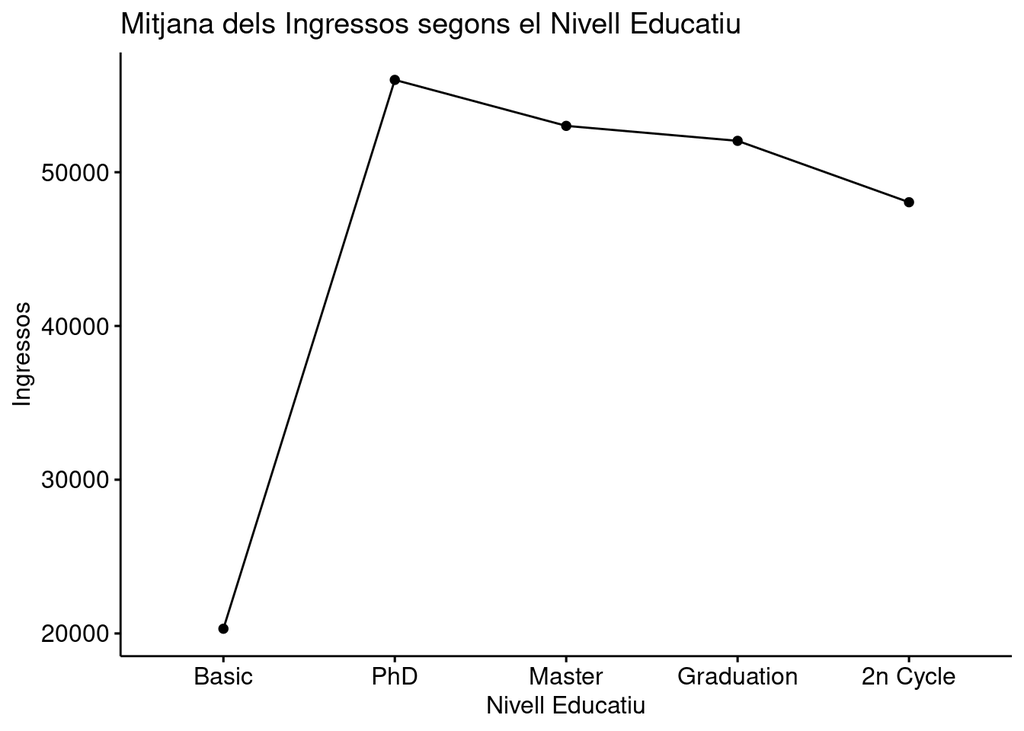

```r
library(ggplot2)
library(ggpubr)

ggline(markclean, x = "Education", y = "Income",
       add = "mean",
       ylab = "Ingressos",
       xlab = "Nivell Educatiu",
       title = "Mitjana dels Ingressos segons el Nivell Educatiu")
```

Podem veure com els ingressos augmenten de forma considerable a mesura que també ho fa el nivell educatiu. El nivell **PhD** presenta la mitjana més alta. Aquests resultats són consistents amb els obtingut en l’anàlisi fet anteriorment.

## Hipòtesi nul·la i alternativa

- Hipòtesi nul·la: No hi ha diferències significatives en els ingressos mitjants dels diferents grups educatius.

$H_0: \mu_1=\mu_2=\mu_3=\mu_4=\mu_5$

- Hipòtesi alternativa: Almenys una de les mitjanes dels ingressos es diferent.

## Efectes dels nivells del factor i força de relació

Proporcionarem l’estimació de l’efecte dels nivells del factor Education. Calcularem la part de la variabilitat dels ingressos explicada per l’efecte dels nivells (força de relació). És a dir, calcularem $\eta²=\frac{SSB}{SST}$ del model.

```r
anova_model <- aov(Income ~ Education, data = markclean)

anova_summary <- summary(anova_model)
print(anova_summary)
```

```
##               Df    Sum Sq   Mean Sq F value Pr(>F)
## Education      4 6.553e+10 1.638e+10   37.36 <2e-16 ***
## Residuals   2232 9.787e+11 4.385e+08
## ---
## Signif. codes:  0 '***' 0.001 '**' 0.01 '*' 0.05 '.' 0.1 ' ' 1
```

```r
model_coefficients <- summary.lm(anova_model)
print(model_coefficients)
```

```
##
## Call:
## aov(formula = Income ~ Education, data = markclean)
##
## Residuals:
##    Min     1Q Median     3Q    Max
## -51982 -16336   -793  15392 109099
##
## Coefficients:
##                     Estimate Std. Error t value Pr(>|t|)
## (Intercept)            20306       2850   7.126 1.39e-12 ***
## EducationPhD           35699       3004  11.884  < 2e-16 ***
## EducationMaster        32707       3050  10.722  < 2e-16 ***
## EducationGraduation    31734       2917  10.879  < 2e-16 ***
## Education2n Cycle      27741       3210   8.643  < 2e-16 ***
## ---
## Signif. codes:  0 '***' 0.001 '**' 0.01 '*' 0.05 '.' 0.1 ' ' 1
##
## Residual standard error: 20940 on 2232 degrees of freedom
## Multiple R-squared:  0.06276,    Adjusted R-squared:  0.06108
## F-statistic: 37.36 on 4 and 2232 DF,  p-value: < 2.2e-16
```

```r
anova_table <- anova(anova_model)

SSB <- anova_table["Education", "Sum Sq"]
SST <- sum(anova_table[ , "Sum Sq"])

eta_squared <- SSB / SST
cat("η² =", eta_squared, "\n")
```

```
## η² = 0.06275875
```

Els coeficients del model ANOVA ens proporcionen l’estimació de l’efecte dels nivells del factor Education en els ingressos. Podem veure que tots els coeficients són estadísticament significatius (valor p < 2e-16), així que hi ha diferències significatives en els ingressos segons el nivell educatiu.

El valor de $eta²$ ens indica que aproximadament el 6.28% de la variabilitat total dels ingressos pot ser explicada en funció del nivell educatiu. Tot i que l’educació és un factor important, hi ha altres factors que contribueixen més a la variabilitat dels ingressos.

## Normalitat dels residus

Per avaluar la normalitat dels residus del model ANOVA, utilitzarem el gràfic normal QQ i el test Shapiro-Willk.

- El gràfic normal QQ ens ajudarà a visualitzar si els residus segueixen una distribució normal.
- El test Shapiro-Wilk és un test estadístic que ens ajudarà a avaluar la normalitat dels residus. La hipòtesi nul·la del test és que els residus segueixen una distribució normal. Si el valor p és menor que el nivell de significança, rebutjarem la hipòtesi nul·la i direm que els residus no segueixen una distribució normal.

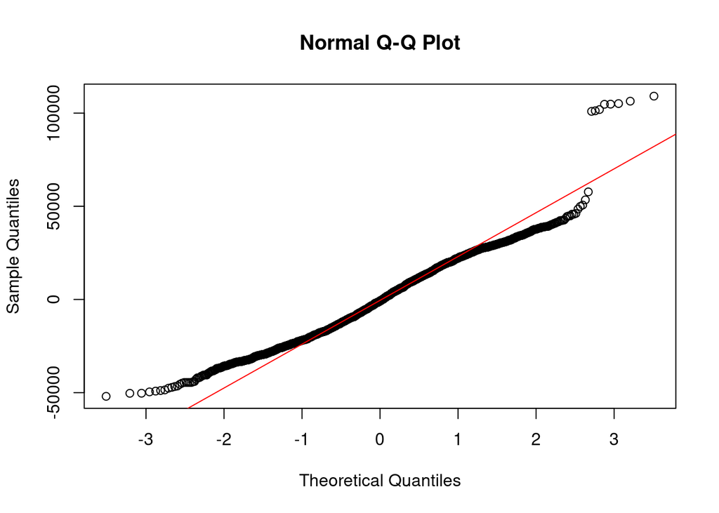

```r
residuals_anova <- residuals(anova_model)

qqnorm(residuals_anova)
qqline(residuals_anova, col = "red")
```

```r
shapiro_test <- shapiro.test(residuals_anova)
print(shapiro_test)
```

```
##
##  Shapiro-Wilk normality test
##
## data:  residuals_anova
## W = 0.97505, p-value < 2.2e-16
```

Observant el gràfic Normal QQ podem veure que els punts no segueixen exactament una línia recta, sobretot als extrems, indicant la presència de valors atípics.

Donat el baix valor del **p-value** rebutgem la hipòtesi nul·la, és a dir, hi ha prou evidència com per dir que els residus no segueixen una dsitribució normal.

**Homocedasticitat dels residus** El gràfic “Residuals vs Fitted” proporciona informació sobre la homoce- dasticitat dels residus. Mostreu i interpreteu aquest gràfic.

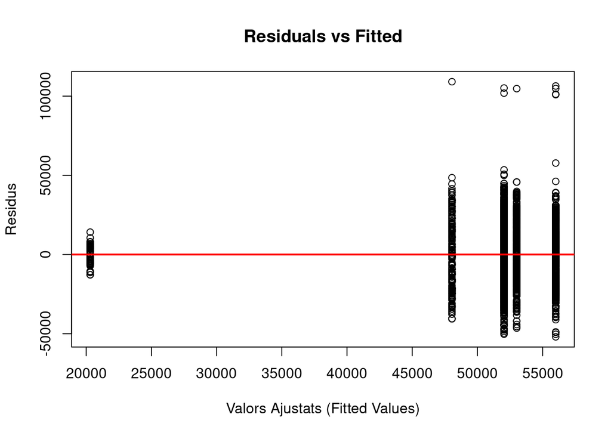

```r
fitted_values <- fitted(anova_model)

plot(fitted_values, residuals_anova,
     xlab = "Valors Ajustats (Fitted Values)",
     ylab = "Residus",
     main = "Residuals vs Fitted")
abline(h = 0, col = "red", lwd = 2)
```

Podem veure que els residus estan dispersos de manera desigual al voltant de la línia horitzontal de zero. També hi ha una concentració de residus per als valors ajustats més baixos, però una major variabilitat als més alts. Basant-nos en el gràfic podem dir que no hi ha evidència d’homocedasticitat en els residus. Això pot afectar la validesa de les inferències del model, ja que una de les assumpcions d’ANOVA és que la variància dels errors és constant.

# Comparacions múltiples

Amb independència del resultat obtingut en l’apartat anterior, realitzarem un test de comparació múltiple entre els grups amb correcció de Bonferroni. Aquest test s’aplica quan el test ANOVA retorna rebutjar la hipòtesi nul·la d’igualtat de mitjanes.

```r
pairwise_results <- pairwise.t.test(markclean$Income, markclean$Education, p.adjust.method = "bonferroni")
print(pairwise_results)
```

```
##
##  Pairwise comparisons using t tests with pooled SD
##
## data:  markclean$Income and markclean$Education
##
##            Basic   PhD     Master Graduation
## PhD        < 2e-16 -       -      -
## Master     < 2e-16 0.386   -      -
## Graduation < 2e-16 0.005   1.000  -
## 2n Cycle   < 2e-16 6.2e-05 0.068  0.128
##
## P value adjustment method: bonferroni
```

- Totes les comparacions entre **Basic** i altres nivells educatius tenen **p-values** molt petits, indicant diferències significatives en els ingressos.
- No hi ha diferències significatives en els ingressos entre PhD i Master, i entre Master i Graduation.
- Hi ha diferències significatives en els ingressos entre PhD i Graduation, i entre PhD i 2n Cycle.
- No hi ha diferències significatives en els ingressos entre Graduation i 2n Cycle, i entre Master i 2n Cycle.

# ANOVA multifactorial

A continuació, es desitja avaluar l’efecte sobre Income del nivell educatiu combinat amb si accepta o no l’oferta de l’última campanya.

## Anàlisi visual dels efectes principals i possibles interaccions

Dibuixarem en un gràfic la variable Income en funció de Education i en funció de Response. El gràfic ha de permetre avaluar si hi ha interacció entre els dos factors.

1. Agruparem el conjunt de dades per Education i per Response. Calcularem la mitjana d’ingressos per a cada grup. Mostrem el conjunt de dades en forma de taula (data frame), on es mostri la mitjana de cada grup segons Education i Response.

```r
mean_income_by_group <- markclean %>%
  group_by(Education, Response) %>%
  summarise(Mean_Income = mean(Income, na.rm = TRUE))
print(mean_income_by_group)
```

```
## # A tibble: 10 × 3
## # Groups:   Education [5]
##    Education  Response Mean_Income
##    <fct>         <int>       <dbl>
##  1 Basic             0      20377.
##  2 Basic             1      18456
##  3 PhD               0      54538.
##  4 PhD               1      61581.
##  5 Master            0      51880.
##  6 Master            1      59241.
##  7 Graduation        0      50656.
##  8 Graduation        1      60920.
##  9 2n Cycle          0      47089.
## 10 2n Cycle          1      55849.
```

2. Mostrem en un gràfic el valor mitjà de la variable Income per a cada factor. Interpretem el resultat sobre si només hi ha efectes principals o hi ha interacció entre els factors.

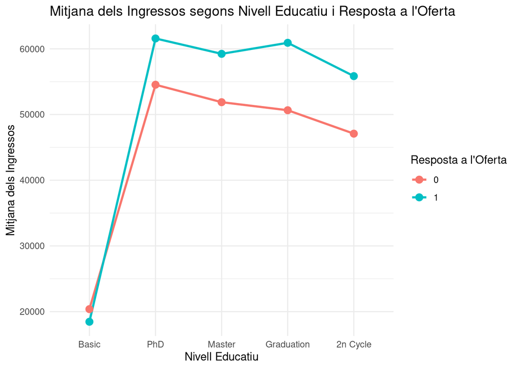

```r
ggplot(mean_income_by_group, aes(x = Education, y = Mean_Income, color = as.factor(Response), group = Response)) +
  geom_line(linewidth = 1) +
  geom_point(size = 3) +
  labs(title = "Mitjana dels Ingressos segons Nivell Educatiu i Resposta a l'Oferta",
       x = "Nivell Educatiu",
       y = "Mitjana dels Ingressos",
       color = "Resposta a l'Oferta") +
  theme_minimal()
```

Al gràfic hi observem que tant l’educació com la resposta tenen relació amb els ingressos.

## Càlcul del model

Analitzem la interacció entre els factors Education i Response en relació a la variable Income.

```r
anova_multifactorial <- aov(Income ~ Education * Response, data = markclean)

summary(anova_multifactorial)
```

```
##                      Df    Sum Sq   Mean Sq F value   Pr(>F)
## Education             4 6.553e+10 1.638e+10  38.136  < 2e-16 ***
## Response              1 2.110e+10 2.110e+10  49.114 3.19e-12 ***
## Education:Response    4 8.450e+08 2.112e+08   0.492    0.742
## Residuals          2227 9.567e+11 4.296e+08
## ---
## Signif. codes:  0 '***' 0.001 '**' 0.01 '*' 0.05 '.' 0.1 ' ' 1
```

## Interpretació dels resultats

Tant el nivell educatiu com la resposta a l’oferta ens indiquen que hi ha diferències significatives. En canvi, la interacció entre l’educació i la resposta no és significativa, cosa que ens indica que l’efecte del nivell educatiu sobre els ingressos no depèn se si s’ha acceptat o no l’oferta. Els efectes dels dos factors són independents l’un de l’altre.

# Resum executiu

L’objectiu d’aquest estudi és entendre les diferències en els ingressos dels clients en funció del seu nivell educatiu i la seva facilitat per acceptar una oferta en l’última campanya. Els resultats obtinguts ens han proporcionat una informació valuosa per a l’equip de màrqueting i la presa de decisions.

**Principals conclusions**

- Impacte del nivell educatiu en els ingressos: Els clients amb un nivell educatiu més alt tenen ingressos mitjans significativament superiors als clients que no el tenen. Per exemple, els clients amb un doctorat tenen ingressos mitjans notablement més alts que els clients amb només una educació bàsica. Les dades ens han mostrat que l’educació té un efecte positiu i significatiu en els ingressos, així doncs es recomena que els esforços del departament de màrqueting ens centrin en clients amb nivells educatius més alts.
- Facilitat per acceptar l’oferta i ingressos: Els clients que van acceptar l’última oferta tenen ingressos mitjans més alts que aquells no la van acceptar. Això ens indica que els clients amb ingressos més alts són més propensos a respondre positivament a les ofertes.
- Interacció entre el nivell educatiu i l’acceptació de l’oferta: Tot i que tant el nivell educatiu com la resposta a l’oferta tenen efectes independents i significatius sobre els ingressos, no s’ha observat que aquests factors interactuïn entre ells de manera significativa.

**Implicacions per a l’estratègia de màrqueting**

- Tenint en compte que els clients amb nivells educatius més alts i ingressos més alts són més propensos a acceptar ofertes, recomanem segmentar les campanyes i dirigir-les específicament a aquests grups.
- Es podria considerar la creació d’ofertes personalitzades per a clients amb ingressos i nivells educatius més alts, cosa que podria augmentar l’eficàcia de les campanyes.